# keep_md:true

### 4. Make histogram, calculate and report the mean and median total number of steps taken per day.

### Histogram- Filled Data:

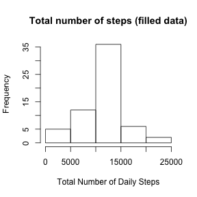

```r
    #As before, reshape data for ease in determining the mean and median.
    melted <- melt(rawdata,id=c(2:3),measure=c(1),na.rm=TRUE)
    sumsteps2 <- dcast(melted, date~variable,sum)
    #One for the output
    hist(sumsteps2$steps,xlab="Total Number of Daily Steps",
         main="Total number of steps (filled data)")
```

```r
    #Generate a plot that can be checked into github or attached to some
    #other document...
    png(file="filledhist.png",height=480,width=480)
    hist(sumsteps2$steps,xlab="Total Number of Daily Steps",
         main="Total Number of steps (filled data)")
    dev.off()
```

### Comments:

Replacing the missing data with the average number of steps (that correspond to the time interval) increased the frequency of the number of averages steps but did not change the “shape” of the histogram.

### Filled Data-Mean total number of steps taken per day:

```r
    meansteps2 <- mean(sumsteps2$steps)
    print(meansteps2)
```

```
## [1] 10766.19
```

#### Filled Data-Median number of total daily steps:

```r
    mediansteps2 <- median(sumsteps2$steps)
    print(mediansteps2)
```

```
## [1] 10766.19
```

## Are there differences in activity patterns between weekdays and weekends?

```r
    #Convert the string date into Date objects
    rawdata$date <- as.Date(rawdata$date)
    #Determine which dates are weekends or weekdays
    wday <- weekdays(rawdata$date)
    for(i in 1:length(wday)){
       if (wday[i] =="Sunday" || wday[i] =="Saturday"){
           wday[i] = "weekend"
       }
       else{
          wday[i] = "weekday"
      }
    }
    dayofweek <- as.factor(wday)

    #Add the days of the week to the data frame, subset the data into weekend
    #and weekday, then reshape to determine the mean.
    rawdata$dayofweek <-cbind(c(wday))
    weekdays.data <- subset(rawdata,dayofweek=="weekday")
    weekends.data <- subset(rawdata,dayofweek=="weekend")
    melted.weekday <- melt(weekdays.data,id=c(2:4),measure=c(1),na.rm=FALSE)
    melted.weekend <- melt(weekends.data, id=c(2:4),measure=c(1),na.rm=FALSE)
    meantimeseries.weekday <- dcast(melted.weekday,interval~variable,mean)
    meantimeseries.weekend <- dcast(melted.weekend,interval~variable,mean)

    #Generate the panel of time series plots.
    png(file="dayofweek.png", height=480, width=480)
    par(mfrow=c(2,1))
    plot(meantimeseries.weekday$interval,
         meantimeseries.weekday$step,type="l",
         xlab="Time Interval (seconds)",
         ylab="Number of steps",
         main="Weekdays")

    plot(meantimeseries.weekend$interval,
         meantimeseries.weekend$step,type="l",
         xlab="Time Interval (seconds)",
         ylab="Number of steps",
         main="Weekends")

   dev.off()
```

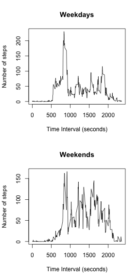

```r
   #Generate the panel plot that is viewable from knitr output
   par(mfrow=c(2,1))
   plot(meantimeseries.weekday$interval,
        meantimeseries.weekday$step,type="l",
        xlab="Time Interval (seconds)",
        ylab="Number of steps",
        main="Weekdays")

  plot(meantimeseries.weekend$interval,
        meantimeseries.weekend$step,type="l",
        xlab="Time Interval (seconds)",
        ylab="Number of steps",
        main="Weekends")
```

### Comments:

There are more steps taken throughout the day on weekends, especially from the 1000 sec to ~1800 sec interval. The number of steps taken are also taken later on the weekend mornings, consistent with sleeping-in on the weekends.